# Smoking and COVID Living Review (v10): a bayesian analysis

## Results

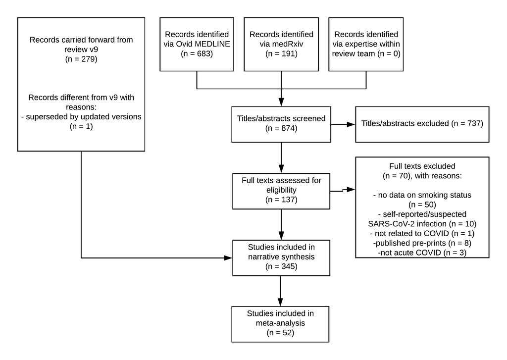

*Figure 1.* PRISMA flow diagram of included studies.

Characteristics of included studies are presented in Table 1. Studies were conducted across 39 countries. 94 studies were conducted in the USA, 65 in China, 36 in the UK, 24 in Spain, 18 in France, 17 in Mexico, 14 in Italy, 9 in Multiple, 6 in Brazil, 5 in Iran and Israel, 4 in Turkey, 3 in Australia, Finland, Saudi Arabia, and Switzerland, with 2 each from Austria, Bangladesh, Chile, Colombia, Denmark, Egypt, Germany, India, Japan, Kuwait, Netherlands, Qatar, and South Korea and a single study from 11 further countries. The majority of studies used observational designs (see Supplementary table S1). 224 (64.7%) were conducted in hospital settings, 92 studies (26.6%) included individuals from community and hospital settings, 27 studies (7.8%) were conducted exclusively in the community, with one study each conducted in a homeless shelter and a quarantine centre, and one study that did not state the study setting. Studies had a median of 453 (interquartile range = 135-1746) participants. The majority of studies (86.5%) used reverse transcriptase polymerase chain reaction (RT-PCR) for confirmation of SARS-CoV-2 infection, 9.6% used an antibody test to confirm prior infection and 3.9 of studies relied on a combination of RT-PCR or antibody assays.

### Use of alternative nicotine products

Six studies recorded the use of alternative nicotine products in current and/or former smokers but did not report COVID-19 outcomes stratified by alternative nicotine use (Miyara et al. 2020; Rimland et al. 2020; Girardeau et al. 2020; Ebinger et al. 2020; Islam et al. 2020; Gallichotte et al. 2020).

### Quality appraisal

#### *Table 1.* All studies included in narrative review and meta-analysis

| ref | Lead author | Date published | Country | Sample size | Study setting | Median (IQR) | Female % | Current smoker % | Former smokers % | Current/former smokers % | Never smokers % | Never/unknown smokers % | Missing % | Study quality |
| --- | --- | --- | --- | --- | --- | --- | --- | --- | --- | --- | --- | --- | --- | --- |
| Guan et al. (2020) | Guan, Ni | 2020-02-28 | China | 1,099 | Hospital | 47 (35-58) | 42 | 12 | 2 | - | 84 | - | 1.27 | fair |
| Guan et al. (2020) | Guan, Liang | 2020-03-26 | China | 1,590 | Hospital | 49 (33-64) | 43 | - | - | 7 | 93 | - | 0.00 | poor |
| Lian et al. (n.d.) | Lian | 2020-03-25 | China | 788 | Hospital | NA | 38 | 7 | - | - | - | - | 93.15 | poor |
| Jin et al. (2020) | Jin | 2020-03-24 | China | 651 | Hospital | 46 (32-60) | 49 | 6 | - | - | - | - | 93.70 | poor |
| Chen et al. (2020) | Chen | 2020-03-26 | China | 548 | Hospital | 62 (44-70) | 38 | 4 | 3 | - | - | - | 93.07 | poor |
| Zhou et al. (2020) | Zhou, Yu | 2020-03-11 | China | 191 | Hospital | 56 (46-67) | 38 | 6 | - | - | - | - | 94.24 | poor |
| Mo et al. (n.d.) | Mo | 2020-03-16 | China | 155 | Hospital | 54 (53-66) | 44 | 4 | - | - | - | - | 96.13 | poor |
| Zhang et al. (2020) | Zhang, Dong | 2020-02-19 | China | 140 | Hospital | 57^ (25-87) | 46 | 1 | 5 | - | - | - | 93.57 | poor |
| Wan et al. (2020) | Wan | 2020-03-21 | China | 135 | Hospital | 47 (36-55) | 47 | 7 | - | - | - | - | 93.33 | poor |
| Liu et al. (2020) | Liu, Tao | 2020-02-28 | China | 78 | Hospital | 38 (33-57) | 50 | - | - | 6 | - | - | 93.59 | poor |
| Huang et al. (2020) | Huang, Wang | 2020-01-24 | China | 41 | Hospital | 49 (41-58) | 27 | 7 | - | - | - | - | 92.68 | poor |
| Zhang et al. (2020) | Zhang, Cai | 2020-03-20 | China | 645 | Hospital | NA | 49 | 6 | - | - | - | - | 93.64 | poor |
| Guo et al. (2020) | Guo | 2020-03-27 | China | 187 | Hospital | 59 (45-73) | 51 | 10 | - | - | - | - | 90.37 | poor |
| Liu et al. (2020) | Liu, Ming | 2020-03-12 | China | 41 | Hospital | 39 (30-48) | 58 | 10 | - | - | - | - | 90.24 | poor |
| Huang et al. (2020) | Huang, Yang | 2020-03-05 | China | 36 | Hospital | 69 (60-78) | 31 | - | - | 11 | - | - | 88.89 | poor |
| Xu et al. (2020) | Xu | 2020-03-08 | China | 53 | Hospital | NA | 47 | 11 | - | - | - | - | 88.68 | poor |
| Li et al. (2020) | Li | 2020-02-12 | China | 17 | Hospital | 45 (33-57) | 47 | 18 | - | - | - | - | 82.35 | poor |
| Rentsch et al. (2020) | Rentsch | 2020-04-14 | USA | 3,528 | Community and Hospital | 66 (60-70) | 5 | 27 | 31 | - | 37 | - | 5.30 | fair |
| Hu et al. (2020) | Hu | 2020-03-25 | China | 323 | Hospital | 61^ (23-91) | 49 | - | - | 12 | - | - | 88.24 | poor |
| Wang et al. (2020) | Wang, Pan | 2020-03-24 | China | 125 | Hospital | 41 (26-66) | 43 | - | - | 13 | - | - | 87.20 | poor |
| CDCMMWR (2020) | Chow (US CDC) | 2020-03-31 | USA | 7,162 | Community and Hospital | NA | - | 1 | 2 | - | - | - | 96.36 | poor |
| Dong et al. (2020) | Dong, Cao | 2020-03-20 | China | 9 | Hospital | 44 (30-46) | 67 | 11 | - | - | - | - | 88.89 | poor |
| Kim et al. (2020) | Kim | 2020-04-01 | South Korea | 28 | Hospital | 43 (30-56) | 46 | 18 | - | - | - | - | 82.14 | poor |
| Shi et al. (2020) | Shi, Yu | 2020-03-18 | China | 487 | Hospital | 46 (27-65) | 47 | - | - | 8 | - | - | 91.79 | poor |
| Yang et al. (2020) | Yang, Yu | 2020-02-24 | China | 52 | Hospital | 60 (47-73) | 37 | 4 | - | - | - | - | 96.15 | poor |
| Argenziano et al. (2020) | Argenziano | 2020-04-22 | USA | 1,000 | Hospital | 63 (50-75) | 40 | 5 | 18 | - | 77 | - | 0.00 | fair |
| Solís and Carreño (2020) | Solis | 2020-04-25 | Mexico | 650 | Hospital | 46 (NA) | 42 | 9 | - | - | - | - | 90.62 | poor |
| Richardson et al. (2020) | Richardson | 2020-04-22 | USA | 5,700 | Hospital | 63 (52-75) | 40 | - | - | 10 | 53 | - | 37.42 | poor |
| Fontanet et al. (2020) | Fontanet | 2020-04-23 | France | 661 | Community and Hospital | 37 (16-47) | 62 | 10 | - | - | - | 90 | 0.00 | poor |
| Zheng et al. (2020) | Zheng, Gao | 2020-04-19 | China | 66 | Hospital | 47^ (NA) | 26 | 12 | - | - | - | - | 87.88 | poor |

[output cut: 319 more lines]